# Sampling & Inference

October 14, 2020

## Data Context

Election news is everywhere we look, but gives us an amazing context to explore sampling variability.

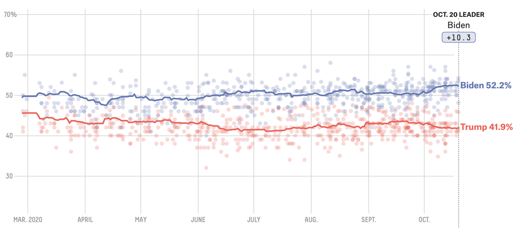

## Sampling

We may be interested in the proportion of US citizens voting for a particular candidate, however it is unreasonable to sample every citizen.

- We take a sample of individuals, with the interest in inferring what we found in our sample to a larger population of individuals.
- We typically only get one sample, but repeated sampling gives us a better idea of the variation in responses.

## Sampling Variation

```
## # A tibble: 30 x 2
##    name       biden
##    <chr>      <chr>
##  1 Brittany   yes
##  2 Brandon    no
##  3 Kaazima    yes
##  4 Alexandria no
##  5 Margarita  yes
##  6 Leilani    no
##  7 Noora      no
##  8 Son        yes
##  9 Jehu       no
## 10 Sabrina    yes
## # … with 20 more rows
```

```r
polling %>%
  count(biden)
```

```
## # A tibble: 2 x 2
##   biden     n
##   <chr> <int>
## 1 no       18
## 2 yes      12
```

## Virtual Sampling

Technically there are approximately 250,056,000 people in the US who are of voting age. If we had a record of every person and their vote, we could take repeated samples from this database of votes.

```r
virtual_poll <- polling_large %>%
  rep_sample_n(size = 50, reps = 1000)
```

```
## # A tibble: 50,000 x 3
## # Groups:   replicate [1,000]
##    replicate name     candidate
##        <int> <chr>    <chr>
##  1         1 Logan    Trump
##  2         1 Luis     Biden
##  3         1 Taaj     Trump
##  4         1 Jessica  Biden
##  5         1 Charnae  Biden
##  6         1 Annmarie Biden
##  7         1 Natelie  Trump
##  8         1 Edward   Biden
##  9         1 Nicholas Trump
## 10         1 Benjamin Trump
## # … with 49,990 more rows
```

## Distribution of Proportions for Multiple Samples

```
## # A tibble: 1,000 x 3
##    replicate n_biden prop_biden
##        <int>   <int>      <dbl>
##  1         1      26       0.52
##  2         2      27       0.54
##  3         3      18       0.36
##  4         4      22       0.44
##  5         5      26       0.52
##  6         6      28       0.56
##  7         7      23       0.46
##  8         8      22       0.44
##  9         9      27       0.54
## 10        10      28       0.56
## # … with 990 more rows
```

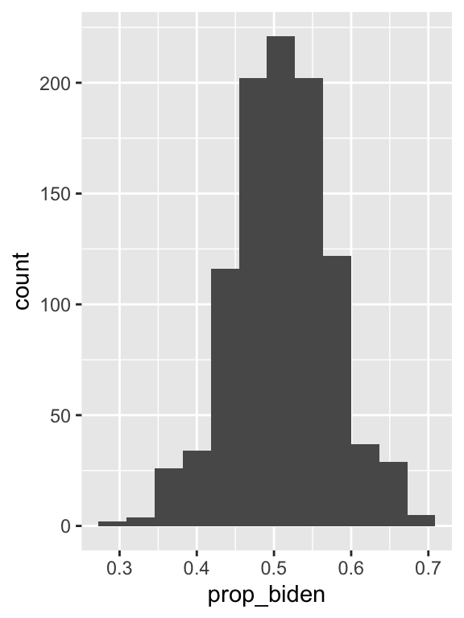

## Sampling Distributions

- Visualize the effect of sampling variation on the distribution of any point estimate – in this case, the sample proportion

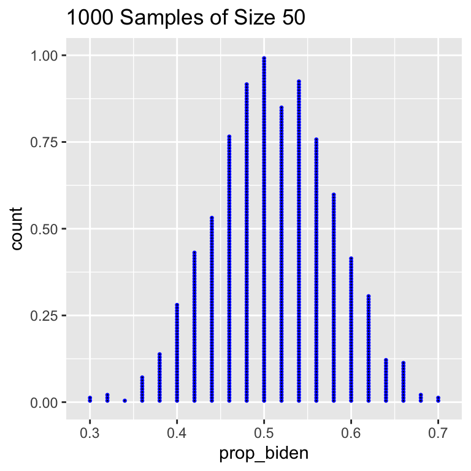

[output not shown]

## Distribution of Proportions for Different Sample Sizes

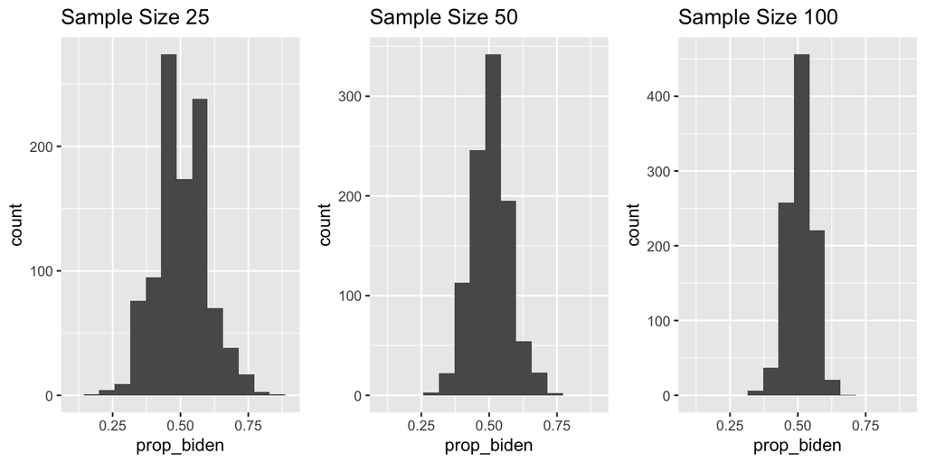

## Standard Deviations for Different Sample Sizes

| Sample Size | Estimate | SD |
| --- | --- | --- |
| n = 25 | 0.534 | 0.0986 |
| n = 50 | 0.529 | 0.0720 |
| n = 100 | 0.527 | 0.0489 |

## Sampling Concepts

- A **population** is a collection of individuals or observations we are interested in.
  - A population **parameter** is a numerical summary quantity about the population that is unknown, but you wish you knew.
- **Sampling** is the act of collecting a sample from the population when we don’t have the means to perform a census.
  - A **point estimate** is a summary statistic computed from a sample that estimates an unknown population parameter.

## Sampling Procedures

- A **census** is an exhaustive enumeration or counting of all individuals.
- A **representative sample** is a sample that looks roughly like the population.
- A **random sample** is a sample where every observation has the same probability of selection.
- A **biased sample** is a sample where certain individuals or observations in a population have a higher chance of being included than others.
- **Generalizability** is when the results from a sample can be *inferred* to the population.

## Precision & Accuracy

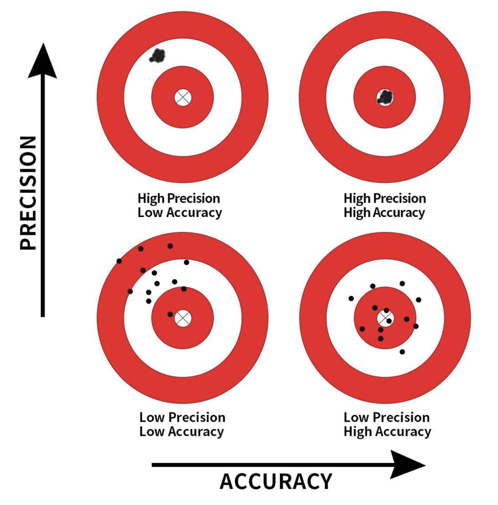

## Your Turn

For the project, you are investigating data on student graduation and receipt of grants. The data come from every accredited college and university in the US & Puerto Rico.

In your project groups address the following questions:

- Who is the study population?
- What type of sample was collected?
- What is the population parameter?
- What is your point estimate / sample statistic?
- Are the samples generalizable to the greater population?